# BayesSMILES

Bayesian Segmentation ModelIng for Longitudinal Epidemiological Studies

### Tutorial

The following script is used to apply the Bayesian hierarchical model to detect multiple change points based on the daily active infectious cases of COVID-19, while estimating the basic reproductive number $R_0$ between all pairs of adjacent change points.

### Load input data

We load the input data for the 50 US states

```r
# load input data information #
load("../Data/USstates_model_input.Rdata")
# The input data for a state (e.g. Texas) is shown below #
knitr::kable(input_data_list[["Texas"]][1:3, ])
```

| I_obs | R_obs | C_obs | population | recovery_rate | time | date | state |
| --- | --- | --- | --- | --- | --- | --- | --- |
| 489 | 154 | 643 | 28996 | 0.1 | 1 | 2020-03-22 | Texas |
| 555 | 203 | 758 | 28996 | 0.1 | 2 | 2020-03-23 | Texas |
| 696 | 259 | 955 | 28996 | 0.1 | 3 | 2020-03-24 | Texas |

The first three columns are

- “I_obs”: daily actively infecious cases
- “R_obs”: daily removed/recovered cases
- “C_obs”: daily confirmed cases

### Select change points and estimate the basic reproduction number

We first load the functions used for our model.

```r
# load R packages
library(Rcpp)
library(loo)
library(mcclust)

# load functions #
source("../functions/functions_JHU.R")
sourceCpp("../functions/covid_poi_fast.cpp")
sourceCpp("../functions/core_5m_sir.cpp")
```

Next, we show how to apply the proposed model into the COVID-19 data for Texas.

```r
input_dataframe = do.call(rbind, input_data_list)
state_idx = which(names(input_data_list) == "Texas")

# detect the change point for Texas #
cp_result = detect_changepoint(input_dataframe,
                               NITER = 10000,
                               state_idx = state_idx,
                               h_vec = c(100000, 10),
                               seed = 1037210)

# estimate the basic reproduction number based on the change point locations #
sir_result = fit_SIR(ret_opt = cp_result)
```

The `cp_result` is a list containing the change point detection results. It has three elements:

1. The best change point detection result determined by the leave-one-out cross validation
2. The input data setting for the corresponding state
3. Setting information for the model fitting

The `sir_result` contains the output from the SIR model. It contains:

1. $R_0$ estimation for each segment and the corresponding 95% credible interval
2. A 7-day prediction for the daily new COVID-19 cases based on the data in the last segment
3. A 7-day prediction for the daily new COVID-19 cases based on the full data

### Visualize the model output

Here, we demonstrate our model results using the COVID-19 data for Texas. Our results include two major component: (1) change piont detection, and (2) basic reproduction number $R_0$ estimation

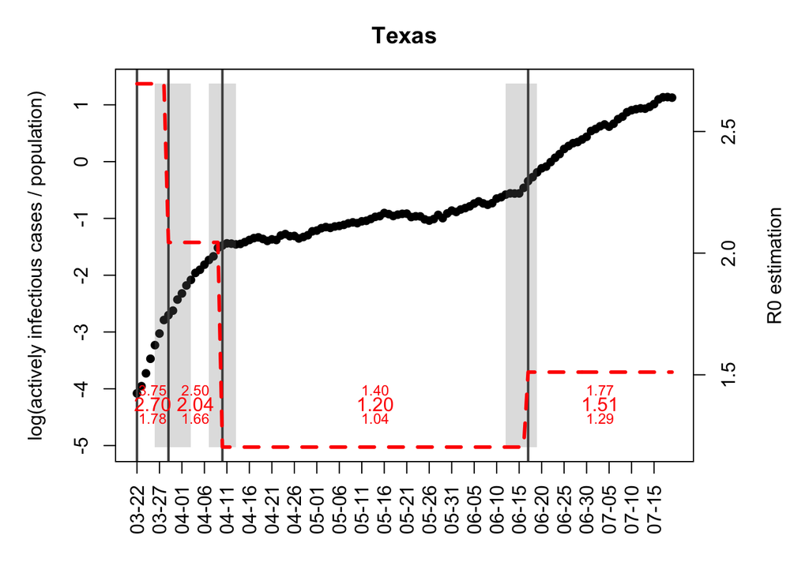

```r
# 1. daily actively infecious counts and date informtion #
n_record = nrow(cp_result$data)
start_day = cp_result$data$date[1]
end_day = cp_result$data$date[n_record]
ref_time = cp_result$data$date
state.nam = unique(cp_result$data$state)
population = cp_result[[1]]$population
time_x_label_red = format(cp_result$data$date, format="%m-%d")
ticks_x_pos = seq(1:n_record)[unlist(lapply(ref_time, function(x){x %in% cp_result$data$date}))]
plot_df = data.frame(count = cp_result$data$I_obs,
                    time = cp_result$data$date,
                    stringsAsFactors = F)
plot_df$count = as.numeric(plot_df$count)
plot_yval = log((plot_df$count + 1)/population)
plot_df$idx = seq(1, nrow(plot_df))
cp_res = cp_result[[1]]
loga_df = cp_res$loga_est
y_range = range(loga_df, plot_yval[!is.na(plot_yval)])
if(max(y_range) > 0){
  y_range = c(min(y_range) * 1.2, max(y_range) * 1.2)
}else{
  y_range = c(min(y_range) * 1.2, max(y_range) / 1.2)
}

# 2. change point location (with confidence interval) information #
gamma_ppm = cp_res$gamma_ppm
cp_df = data.frame(gamma = gamma_ppm,
                    time = cp_result$data$date,
                    lga_mean = loga_df$log_alpha,
                    lga_lower = loga_df$`2.5%`,
                    lga_upper = loga_df$`97.5%`,
                    stringsAsFactors = F)
gamma_plot = as.numeric(cp_df[, 1])

# 3. R_0 estimation for each segment
SIR_res = sir_result[[1]]$full_sir
cp_seg = sum(gamma_plot)
z_vec = cumsum(gamma_plot)
seg_size = as.numeric(table(z_vec))
seg_plot = c(which(gamma_plot == 1), n_record)
seg_len = as.numeric(table(cumsum(gamma_plot)))
seg_len_rep = rep(seg_len, seg_len)
SIR_df = data.frame(z = cumsum(gamma_plot),
                    R0 = rep(SIR_res[, 1], seg_len ))

# 4. generate the plot #
par(mar = c(5, 5, 3, 5))
plot(plot_df$idx, plot_yval, ylim = y_range,
     type = 'b', xaxt="n", xlab = "", pch = 16,
     ylab = 'log(actively infectious cases / population)',
     main = state.nam)
axis(side = 1, at = ticks_x_pos[seq(1, length(ticks_x_pos), by = 5)],
     labels = time_x_label_red[seq(1, length(ticks_x_pos), by = 5)], las=2)

# (1) Confidence intervals for each change point #
gamma.idx = which(gamma_plot == 1)[-1]
gamma.ci.list = cp_result[[1]]$change_point_details
for(ii in 1:length(gamma.idx)){
  cp.detail = gamma.ci.list[[ii]]
  rect(min(cp.detail$cp.ci),min(y_range),
       max(cp.detail$cp.ci),
       max(y_range),border = NA,
       col = rgb(0.5,0.5,0.5,1/4))
}

# (2) R_0 estimation for each segment
abline(v = which(gamma_plot == 1), col = 'gray30', lwd = 2)
invisible(lapply(1:(cp_seg), function(i){
  x_pos = mean(c(seg_plot[i], seg_plot[i + 1]));
  y_pos = min(y_range) * 0.85;
  text(x_pos, y_pos, format(round(SIR_res[i, 1], 2), nsmall = 2),
         col = 'red' )

}) )

invisible(lapply(1:(cp_seg), function(i){
  x_pos = mean(c(seg_plot[i], seg_plot[i + 1]));
  y_pos = min(y_range) * 0.9;
  text(x_pos, y_pos, format(round(SIR_res[i, 2], 2), nsmall = 2),
         cex = 0.75,col = 'red' )
}) )

invisible(lapply(1:(cp_seg), function(i){
  x_pos = mean(c(seg_plot[i], seg_plot[i + 1]));
  y_pos = min(y_range) * 0.8;
  text(x_pos, y_pos, format(round(SIR_res[i, 3], 2), nsmall = 2),
         cex = 0.75,col = 'red' )
}) )

# (3) Trend of change in R_0 #
par(new = TRUE)
plot(plot_df$idx,SIR_df$R0, type = "l", xaxt = "n", yaxt = "n",
     ylab = " ", xlab = "", col = "red", lty = 2, lwd = 3)
axis(side = 4)
mtext("R0 estimation", side = 4, line = 3)
```